# communicate-data-findings(fordgobike-tripdata)

## Investigation Overview

> I want to test consumer rental actions in this study. The emphasis will be on gender rental behaviour.

## Dataset Overview

> At the end of 2018, Ford GoBike will cross 7,000 motorcycles at 546 stops and will be the second-largest cycling sharing network in the world. The scheme in San Francisco has already expanded to 1,750 bikes by the end of the year. New cycle sharing. The East Bay and San Jose expansions are set to commence on the week of 10 July. In the press event held yesterday, the initial 700-cycle fleet, introduced as a pilot project in 2013 as the Bay Area Bike Share, was "very modest but successful," "Today marks the day we build on that success and blow it out of the water, increasing bike-share in the region by tenfold." (I've reached that information through this blog:https://www.sfmta.com/videos/regional-leaders-announce-ford-gobike-expansion)

```python
import numpy as np
import pandas as pd
import matplotlib.pyplot as plt
plt.style.available
import seaborn as sb
import seaborn as sns
from requests import get
from datetime import datetime
import json
import datetime
import math
import calendar
import warnings
import os
import glob
from datetime import timedelta, datetime
from matplotlib.pyplot import figure
from zipfile import ZipFile
from sklearn import datasets
from IPython.display import Image
from matplotlib.patches import Polygon
from matplotlib.lines import Line2D
import matplotlib.ticker as tick
import matplotlib.dates as mdates
from matplotlib.artist import Artist
from pandas.plotting import scatter_matrix
from os import path, getcwd, makedirs, listdir
from io import BytesIO
import matplotlib.pyplot as plt
import matplotlib.ticker as ticker

import matplotlib.mlab as mlab
import matplotlib
%matplotlib inline
import warnings
warnings.simplefilter("ignore")
```

```python
# load in the dataset into a pandas dataframe
df= pd.read_csv('201902-fordgobike-tripdata.csv')
df.head()
```

|  | duration_sec | start_time | end_time | start_station_id | start_station_name | start_station_latitude | start_station_longitude | end_station_id | end_station_name | end_station_latitude | end_station_longitude | bike_id | user_type | member_birth_year | member_gender | bike_share_for_all_trip |
| --- | --- | --- | --- | --- | --- | --- | --- | --- | --- | --- | --- | --- | --- | --- | --- | --- |
| 0 | 52185 | 2019-02-28 17:32:10.1450 | 2019-03-01 08:01:55.9750 | 21.0 | Montgomery St BART Station (Market St at 2nd St) | 37.789625 | -122.400811 | 13.0 | Commercial St at Montgomery St | 37.794231 | -122.402923 | 4902 | Customer | 1984.0 | Male | No |
| 1 | 42521 | 2019-02-28 18:53:21.7890 | 2019-03-01 06:42:03.0560 | 23.0 | The Embarcadero at Steuart St | 37.791464 | -122.391034 | 81.0 | Berry St at 4th St | 37.775880 | -122.393170 | 2535 | Customer | NaN | NaN | No |
| 2 | 61854 | 2019-02-28 12:13:13.2180 | 2019-03-01 05:24:08.1460 | 86.0 | Market St at Dolores St | 37.769305 | -122.426826 | 3.0 | Powell St BART Station (Market St at 4th St) | 37.786375 | -122.404904 | 5905 | Customer | 1972.0 | Male | No |
| 3 | 36490 | 2019-02-28 17:54:26.0100 | 2019-03-01 04:02:36.8420 | 375.0 | Grove St at Masonic Ave | 37.774836 | -122.446546 | 70.0 | Central Ave at Fell St | 37.773311 | -122.444293 | 6638 | Subscriber | 1989.0 | Other | No |
| 4 | 1585 | 2019-02-28 23:54:18.5490 | 2019-03-01 00:20:44.0740 | 7.0 | Frank H Ogawa Plaza | 37.804562 | -122.271738 | 222.0 | 10th Ave at E 15th St | 37.792714 | -122.248780 | 4898 | Subscriber | 1974.0 | Male | Yes |

> Note that the above cells have been set as "Skip"-type slides. That means that when the notebook is rendered as http slides, those cells won't show up.

## (Visualization 1)

> Percentage of all bike rides per gender

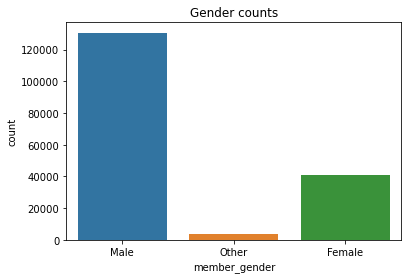

```python
sb.countplot(data = df, x = 'member_gender')
plt.title('Gender counts');
```

## (Visualization 2)

> The percentage of participation according to gender

```python
def PropByVar(df, variable):
    df_pie = df[variable].value_counts()
    ax = df_pie.plot.pie(figsize=(10,10), autopct='%1.2f%%', fontsize = 12);
    ax.set_title(variable + ' (%) \n', fontsize = 15);
    return np.round(df_pie/df.shape[0]*100,2)
```

```
Total =  183412
member_gender =  0 %
```

```
Male      71.23
Female    22.27
Other      1.99
Name: member_gender, dtype: float64
```

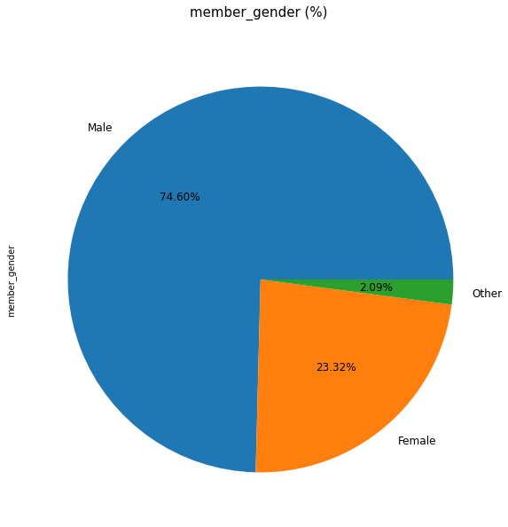

```python
total = len(df.index)
print('Total = ', total)
total_noshow = (df['member_gender'] == 'Yes').sum()
print('member_gender = ', int((total_noshow / total) * 100), '%')
PropByVar(df, 'member_gender')
```

This chart displays the user form percentage by the amount registered

## (Visualization 3)

> Percentage of Bike Rides for user type acorrding to gender

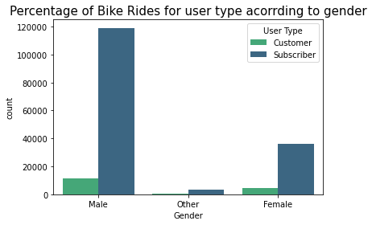

```python
base_color = sb.color_palette()[0]
sns.countplot(data=df, x='member_gender', hue='user_type', color=base_color, palette='viridis_r')
ax = plt.gca()
ax.legend().set_title('User Type')
ax.set_ylabel('count')
ax.set_xlabel('Gender')
ax.set_title("Percentage of Bike Rides for user type acorrding to gender", fontsize=15);
```

This graph brings the previous two together, explaining the convergence numbers of users whether they are Customer or Subscriber taking into account their type.👌

```python
df['start_time']=pd.to_datetime(df['start_time'])
df['end_time']=pd.to_datetime(df['end_time'])

df['start_time_date']=df['start_time'].dt.date
df['end_time_date']=df['end_time'].dt.date

df['start_time_year_month']=df['start_time'].map(lambda x: x.strftime('%Y-%m'))
df['end_time_year_month']=df['end_time'].map(lambda x: x.strftime('%Y-%m'))
df['start_time_year_month_renamed'] = df['start_time'].dt.strftime('%y' + '-' + '%m')

df['start_time_year']=df['start_time'].dt.year.astype(int)
df['end_time_year']=df['end_time'].dt.year.astype(int)

df['start_time_day']=df['start_time'].dt.day.astype(int)
df['start_time_day']=df['start_time'].dt.strftime('%A')

df['start_time_month'] = df['start_time'].dt.strftime('%B')

df['start_time_hour']=df['start_time'].dt.hour
df['end_time_hour']=df['end_time'].dt.hour

df['start_day_of_week'] = df['start_time'].dt.day.astype
df['start_month_of_year'] = df['start_time'].dt.month
df['end_day_of_week'] = df['end_time'].dt.day.astype

df.info()
```

```
<class 'pandas.core.frame.DataFrame'>
RangeIndex: 183412 entries, 0 to 183411
Data columns (total 30 columns):
 #   Column                         Non-Null Count   Dtype
---  ------                         --------------   -----
 0   duration_sec                   183412 non-null  int64
 1   start_time                     183412 non-null  datetime64[ns]
 2   end_time                       183412 non-null  datetime64[ns]
 3   start_station_id               183215 non-null  float64
 4   start_station_name             183215 non-null  object
 5   start_station_latitude         183412 non-null  float64
 6   start_station_longitude        183412 non-null  float64
 7   end_station_id                 183215 non-null  float64
 8   end_station_name               183215 non-null  object
 9   end_station_latitude           183412 non-null  float64
```

[output cut: 22 more lines]

```python
df.columns
```

```
Index(['duration_sec', 'start_time', 'end_time', 'start_station_id',
       'start_station_name', 'start_station_latitude',
       'start_station_longitude', 'end_station_id', 'end_station_name',
       'end_station_latitude', 'end_station_longitude', 'bike_id', 'user_type',
       'member_birth_year', 'member_gender', 'bike_share_for_all_trip',
       'start_time_date', 'end_time_date', 'start_time_year_month',
       'end_time_year_month', 'start_time_year_month_renamed',
       'start_time_year', 'end_time_year', 'start_time_day',
       'start_time_month', 'start_time_hour', 'end_time_hour',
       'start_day_of_week', 'start_month_of_year', 'end_day_of_week'],
      dtype='object')
```

# Visualization 4

> Trip distribution over day hours. Note: 0 means 12 AM, 23 means 11 PM

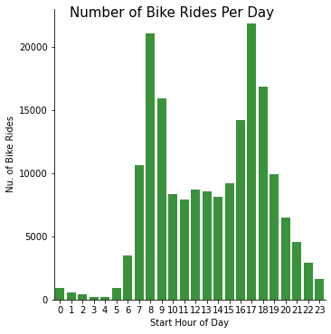

```python
base_color = sb.color_palette()[2]
lm=sns.catplot(data=df, x='start_time_hour', kind='count', color = base_color, height = 5)
lm.set_axis_labels("Start Hour of Day", " Nu. of Bike Rides")
lm.fig.suptitle('Number of Bike Rides Per Day', fontsize=15);
```

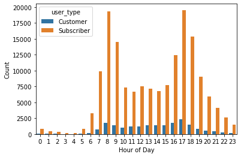

```python
sb.countplot(data=df, x='start_time_hour', hue='user_type');
plt.xlabel('Hour of Day');
plt.ylabel('Count');
```

When people go to work in the morning and get out of work in the afternoon, subscriber use obviously increases in the usual rush hours, their purposed use and target for riding is double verified. There was no common trend among customers who appear to ride the most for a reason separate from the subscriber drivers in the afternoons or early evenings.

# Visualization 5

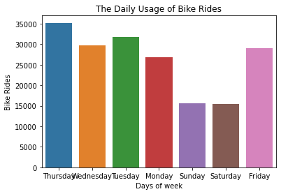

```python
sb.countplot(data = df, x = 'start_time_day')
plt.xlabel(" Days of week ")
plt.ylabel("Bike Rides")
plt.title('The Daily Usage of Bike Rides');
```

> Once you're ready to finish your presentation, check your output by using nbconvert to export the notebook and set up a server for the slides. From the terminal or command line, use the following expression:

> > `jupyter nbconvert <file_name>.ipynb --to slides --post serve --template output_toggle`

> This should open a tab in your web browser where you can scroll through your presentation. Sub-slides can be accessed by pressing 'down' when viewing its parent slide. Make sure you remove all of the quote-formatted guide notes like this one before you finish your presentation!

```python
!jupyter nbconvert exploration_Ford_GoBike_slide.ipynb --to slides --no-input
```

```
[NbConvertApp] Converting notebook exploration_Ford_GoBike_slide.ipynb to slides
[NbConvertApp] Writing 682406 bytes to exploration_Ford_GoBike_slide.slides.html
```